# Analysis of Daily Phone Usage Patterns

## Introduction

This visual data story explores patterns in daily phone usage. The data was collected through logging of phone usage events over time. The analysis focuses on which apps consumed the most time, when phone usage occurred most often, and how long different phone sessions lasted.

## Which Apps Took the Most Time?

This visualization compares the total minutes spent on each app across all observations. Some apps accounted for larger amounts of total screen time than others. Specifically, the app ‘Gemini’ had a substantially larger amount of total screen time. This is potentially because of the upcoming exam season corresponding with Gemini being only used for studying.

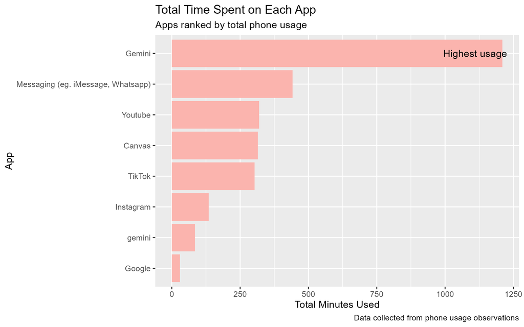

Bar graph showing total minutes used on each app, with Gemini having the highest total usage.

## Phone Usage Throughout the Day

Phone usage varied depending on the time of day. This plot shows how total phone usage changed across different periods of the day. It displays phone usage being lowest in the morning and highest in the evening. Notably, the Evening and Afternoon categories showed very similar distributions of total minutes used.

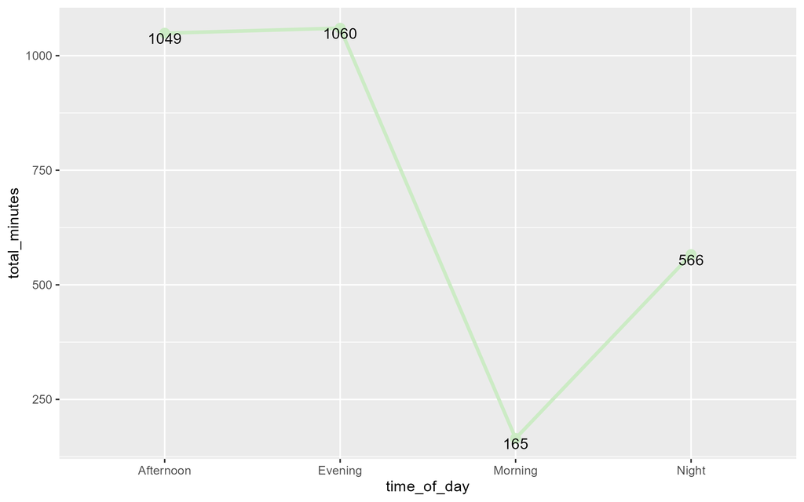

Line graph displaying total phone usage across different times of day, with evening usage being the highest and morning usage being the lowest.

## Comparing Phone Session Lengths

Phone sessions were grouped into short, medium, and long categories to better understand how usage duration differed. The long category is significantly higher than medium and short.

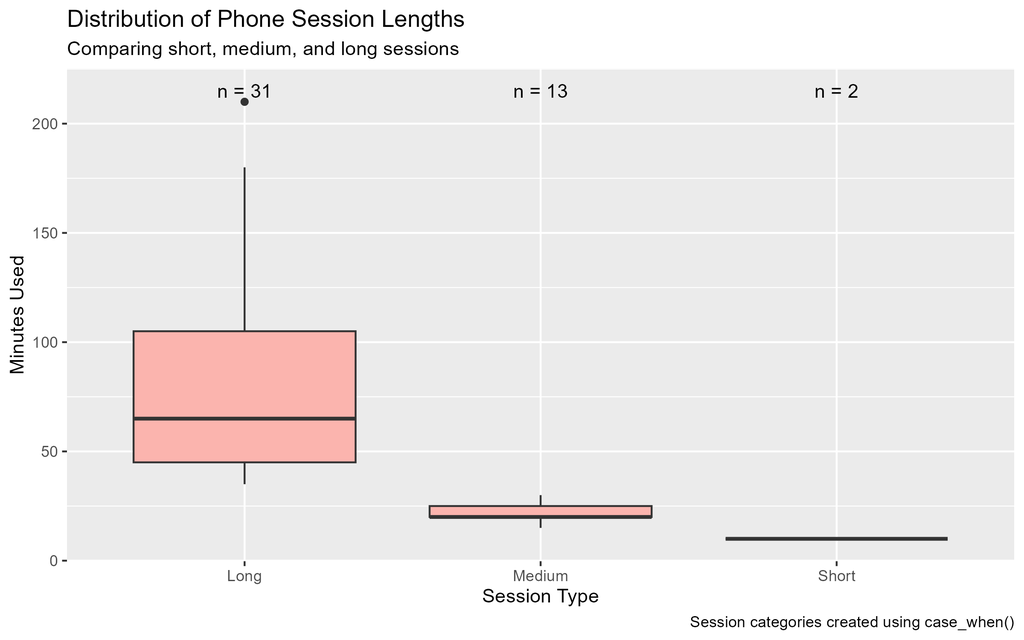

Boxplot comparing the distribution of minutes used across short, medium, and long phone session categories, with long sessions showing the greatest range and highest minutes used. The number annotations above each category represent the count of phone sessions within each group, whereas Session Type categories display minute values distributions across the created short, medium, and long categories

## Submission Time Patterns

Timestamp data was analysed using lubridate to investigate what hours of the day observations were submitted. This plot did not display much variability due to the data collection method, as the observations were logged simultaneously using already collected phone usage reports from device settings. The dominant submission according to the 24-hour clock is hour 15.

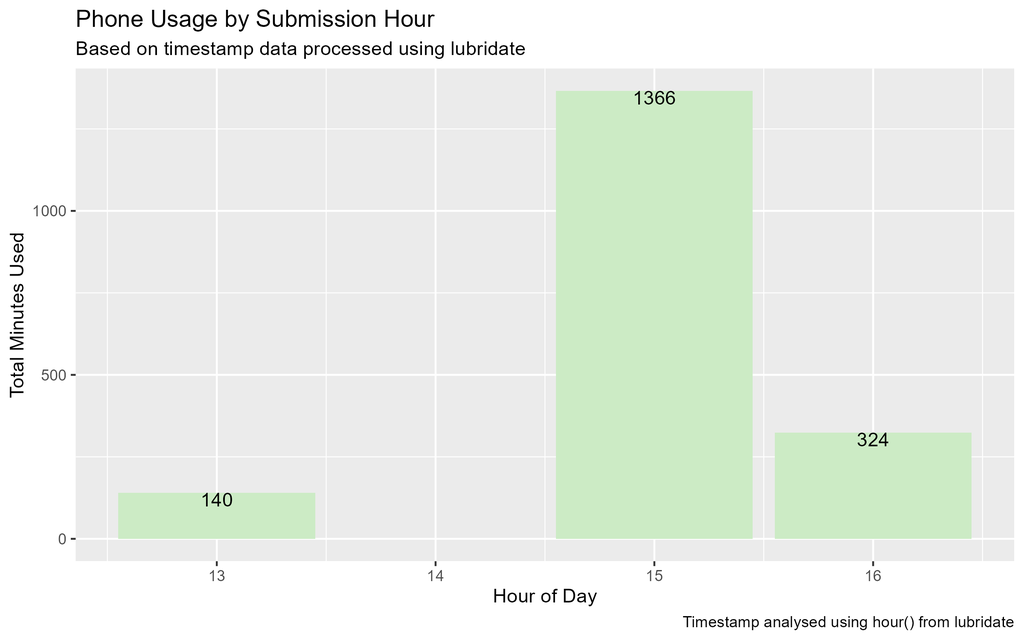

Bar graph showing total phone usage by submission hour using a 24-hour clock, with hour 15 having the highest total minutes.

## Conclusion

Overall, the data suggests that phone usage patterns changed depending on the time of day, with phone usage being lowest in the morning and highest in the evening. The visualizations also showed that certain apps contributed more heavily to overall screen time, particularly Gemini, which may reflect my increased studying during the upcoming exam season. In addition, longer phone sessions accounted for a much larger distribution of minutes used compared with short and medium sessions. While the timestamp submission data showed limited variability due to the logging method, the visualizations were still useful for identifying general trends in my phone behaviour through different types of plots.